# Hotspot Project

Sydney Bales

03 July 2023

# PACKAGES

Here are the packages I need to create this model:

```r
library(tidyverse)
library(leaflet)
library(sf)
library(tigris)
```

# DATA

### Get Data

#### Calls for Service

```r
id.calls <- "1gRoL7lZlwm7sreA5F9WbPoH5su4n4iGS"
calls.temp <- read.csv(sprintf("https://docs.google.com/uc?id=%s&export=download", id.calls))
```

#### Geogrpahic data

```r
fairfax.roads <- roads ("VA", "Fairfax city")
fairfax.city <- county_subdivisions("VA", "Fairfax city")
```

### Clean Data

```r
calls.temp$date <- as.Date(calls.temp$date)
calls.temp$dow <- weekdays(calls.temp$date)
calls.temp$month <- substr(calls.temp$date, 6, 7)
calls.full <- subset(calls.temp, !is.na(calls.temp$lat))
```

### Calculations

```r
calls.year <- calls.full %>%
  group_by(year) %>%
  summarise(count = n()) %>%
  mutate(PCT = round(count/sum(count)*100,2))
```

```r
calls.type <- calls.full %>%
  group_by(type) %>%
  summarise(count = n()) %>%
  mutate(PCT = round(count/sum(count)*100,2))
```

```r
calls.type <- calls.type[order(-calls.type$count),]
diffs <- diff(calls.type$PCT)
diffs <- c(0, diffs)
calls.type$diff <- diffs
```

### Select Data

```r
calls <- subset(calls.full, calls.full$type == 'WARRANT')
```

# Coutour Plot Maps

### Map 1: Day of Week

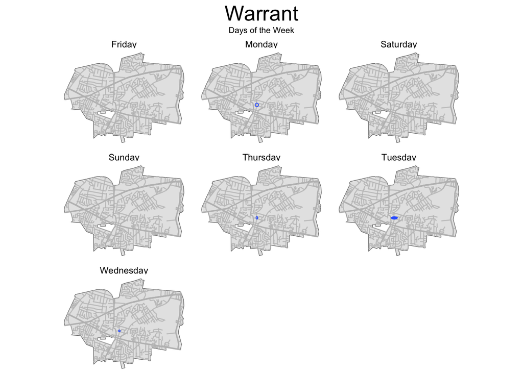

```r
ggplot() +
  geom_sf(data = fairfax.city) +
  geom_sf(data = fairfax.roads,  inherit.aes = FALSE, color = "grey", size = .3, alpha = .75) +
  geom_density2d(data = calls, aes(x = lon, y = lat), size = 0.35)  +
  theme_void() +
  theme(plot.title = element_text(size = 20, hjust=.5), plot.subtitle = element_text(size = 8, hjust=.5, margin=margin(2, 0, 5, 0))) +
  labs(title = "Warrant", subtitle = "Days of the Week") +
  facet_wrap(~ dow, nrow = 3)
```

### Analysis #1:

The days of the week have one prominent hotspot on the following days: Monday, Tuesday, Wednesday, and Thursday. The only hotspot that occurs in Downtown is on University and Main St., on Friday, Saturday, and Sunday there are no hotspots. Fairfax, all in all, is a cold spot on these days. In the future, those specific days will always have cold spots; Monday, Tuesday, Wednesday, and Thursday will always have four cold spots, which are the North, South, East, and West. The roads that will remain coldspots are in the North: Chain Bridge Rd., Fairfax Boulevard, and Fairwoods Parkway; in the South: Armstrong St.; in the West: Main St. and Fairfax Blvd.; and in the East: Pickett Rd.

### Map 2: Hour of Day

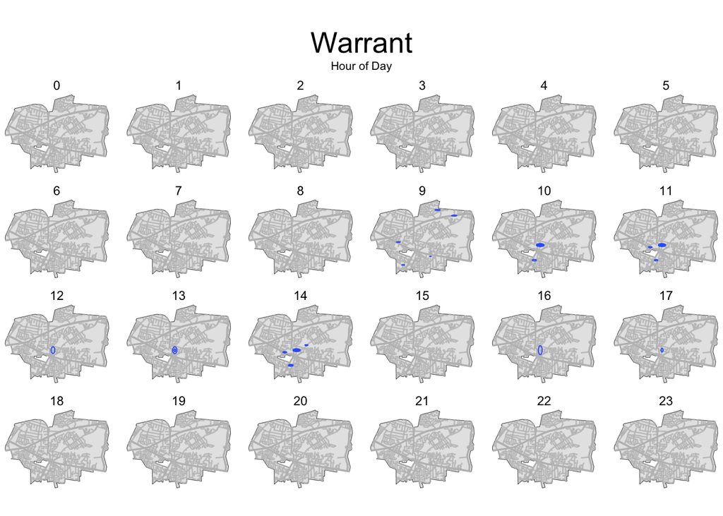

```r
ggplot() +
  geom_sf(data = fairfax.city) +
  geom_sf(data = fairfax.roads, inherit.aes = FALSE, color = "grey", size = .3, alpha = .75) +
  geom_density2d(data = calls, aes(x = lon, y = lat), size = 0.35)  +
  theme_void() +
  theme(plot.title = element_text(size = 20, hjust=.5), plot.subtitle = element_text(size = 8, hjust=.5, margin=margin(2, 0, 5, 0))) +
  labs(title = "Warrant", subtitle = "Hour of Day") +
  facet_wrap(~ hour, nrow = 4)
```

### Analysis #2:

The hour of the day has a variety of hotspots; they are prominent in times 9–14, 16, and 17. Hotspots range from 1–5, with 9 a.m. having the most hotspots in the North, Northeast, Southeast, Southwest, and West. From 10–14, 16, and 17 all have a hotspot in Downtown, 10, 11, and 14 have a hotspot in the south, and 11 and 14 have a hotspot in the West. In the times of 0-8, 15, and 18-23, all of Fairfax is a cold spot, which means most people are not working at those times. In the future, 0-8, 12, 13, and 15-23 will have the same cold spots, which are the North: Chain Bridge Rd., Fairfax Boulevard, and Fairwoods Parkway; the South: Armstrong St.; the West: Main St. and Fairfax Blvd.; and the East: Pickett Rd. the times of 9-11, and 14 will always have a cold spot in the Northwest, which is in Jermantown Rd. In the future, the hotspots of Downtown (University and Main St.) will always occur at 10–14, 16, and 17, at 9 a.m., the hotspots cool off because all the warrants are delivered there at that time, and then they have no more for the rest of the day.

### Map 3: Month of Year

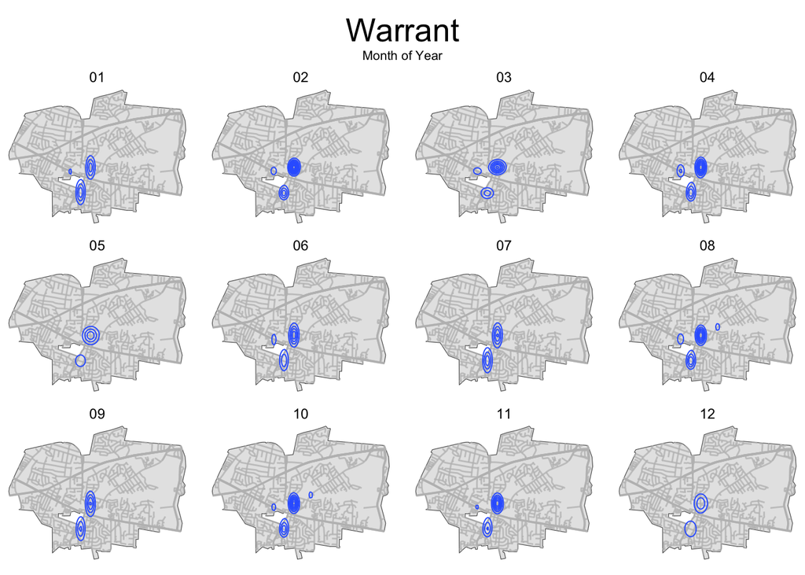

```r
ggplot() +
  geom_sf(data = fairfax.city) +
  geom_sf(data = fairfax.roads, inherit.aes = FALSE, color = "grey", size = .3, alpha = .75) +
  geom_density2d(data = calls, aes(x = lon, y = lat), size = 0.35)  +
  theme_void() +
  theme(plot.title = element_text(size = 20, hjust=.5), plot.subtitle = element_text(size = 8, hjust=.5, margin=margin(2, 0, 5, 0))) +
  labs(title = "Warrant", subtitle = "Month of Year") +
  facet_wrap(~ month, nrow = 3)
```

### Analysis #3:

The months of the year are very consistent, ranging from 2-4; in months 01–04, 06, and 11, they have the same hotspots of Downtown, West, and South. All the months have the same hotspots in Downtown and the South, while the months 05, 07, 09, and 12 lose the hotspot in the West, and 08 and 10 add a hotspot in the Police Department. The cold spots are the same for every month and are in the North, West, and East. In the future, the cold spots will remain the same, consisting of the North: Chain Bridge Rd., Fairfax Boulevard, and Fairwoods Parkway; the West: Main St. and Fairfax Blvd.; and the East: Pickett Rd. Hotspots in downtown (University and Main St.) and in the south (Armstrong St.) will always occur every month, having no acticity in the East because of the Army Navy Country Club and Daniels Run Park, not as many people live in that area. Hotspots like the West (Main St. and Fairfax Blvd.) and the Police Department (Blenheim Rd.) go through periods of cooling off, and that will continue.

### Map 4: Interactive Cluster

```r
leaflet(calls) %>%
  addTiles() %>%
  addMarkers(lng = ~lon, lat = ~lat,
             popup = paste(
               "Call Type: ", calls$type, "<br>",
               "Date:", calls$date),
             clusterOptions = markerClusterOptions()) %>%
  addPolygons(data = fairfax.city)
```

[interactive chart not shown]